# RE6013 Business Analytics

# Loading Data and Imports

Get imports

```r
library(data.table)
library(ggplot2)
library(corrplot)
library(DMwR2)
```

Load data

```r
home.train.dt <- fread("home_train.csv")
home.test.dt <- fread("home_test.csv")
```

# Data Exploration

Create exploration copy

```r
home.exp <- copy(home.train.dt)
```

Basic data check reveal the following continous columns: - Continuous - ApplicantIncome - CoApplicantIncome - LoanAmount - Loan_Amount_Term

Credit_History is actually categorical

```r
summary(home.exp) #13 columns in pattern, including 1 label column
```

```
   Loan_ID             Gender            Married           Dependents         Education         Self_Employed      ApplicantIncome CoapplicantIncome
 Length:614         Length:614         Length:614         Length:614         Length:614         Length:614         Min.   :  150   Min.   :    0
 Class :character   Class :character   Class :character   Class :character   Class :character   Class :character   1st Qu.: 2878   1st Qu.:    0
 Mode  :character   Mode  :character   Mode  :character   Mode  :character   Mode  :character   Mode  :character   Median : 3812   Median : 1188
                                                                                                                   Mean   : 5403   Mean   : 1621
                                                                                                                   3rd Qu.: 5795   3rd Qu.: 2297
                                                                                                                   Max.   :81000   Max.   :41667

   LoanAmount    Loan_Amount_Term Credit_History   Property_Area      Loan_Status
 Min.   :  9.0   Min.   : 12      Min.   :0.0000   Length:614         Length:614
 1st Qu.:100.0   1st Qu.:360      1st Qu.:1.0000   Class :character   Class :character
 Median :128.0   Median :360      Median :1.0000   Mode  :character   Mode  :character
 Mean   :146.4   Mean   :342      Mean   :0.8422
 3rd Qu.:168.0   3rd Qu.:360      3rd Qu.:1.0000
 Max.   :700.0   Max.   :480      Max.   :1.0000
 NA's   :22      NA's   :14       NA's   :50
```

Preview of the values reveal tha Loan_Status is the label column, Categorical and labelled with ‘Y’ and ‘N’

```r
head(home.exp)
```

| Loan_ID | Gender | Married | Dependents | Education | Self_Employed | ApplicantIncome | CoapplicantIncome | LoanAmount | Loan_Amount_Term | Credit_History | Property_Area | Loan_Status |
| --- | --- | --- | --- | --- | --- | --- | --- | --- | --- | --- | --- | --- |
| LP001002 | Male | No | 0 | Graduate | No | 5849 | 0 | NA | 360 | 1 | Urban | Y |
| LP001003 | Male | Yes | 1 | Graduate | No | 4583 | 1508 | 128 | 360 | 1 | Rural | N |
| LP001005 | Male | Yes | 0 | Graduate | Yes | 3000 | 0 | 66 | 360 | 1 | Urban | Y |
| LP001006 | Male | Yes | 0 | Not Graduate | No | 2583 | 2358 | 120 | 360 | 1 | Urban | Y |
| LP001008 | Male | No | 0 | Graduate | No | 6000 | 0 | 141 | 360 | 1 | Urban | Y |
| LP001011 | Male | Yes | 2 | Graduate | Yes | 5417 | 4196 | 267 | 360 | 1 | Urban | Y |

Check distribution of non-continuous variables

We can see missing values in the following non-continuous columns: - Gender: missing is "" - Married: missing is "" - Dependents: missing is "" - Self_Employed: missing is "" - Credit_History: missing is NA

```
Ignoring unknown parameters: binwidth, bins, pad
```

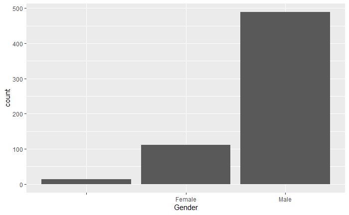

```r
ggplot(home.exp, aes(Gender)) + geom_histogram(stat="count")
```

```
Ignoring unknown parameters: binwidth, bins, pad
```

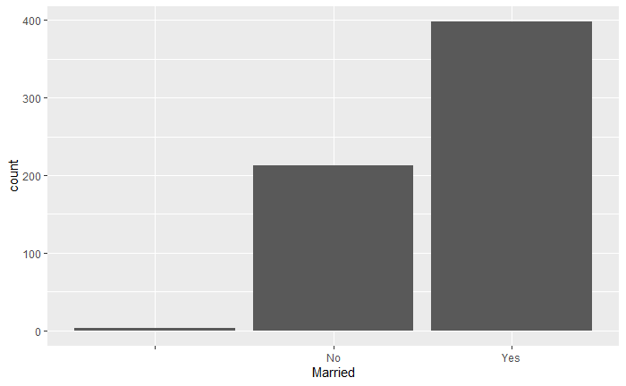

```r
ggplot(home.exp, aes(Married)) + geom_histogram(stat="count")
```

```
Ignoring unknown parameters: binwidth, bins, pad
```

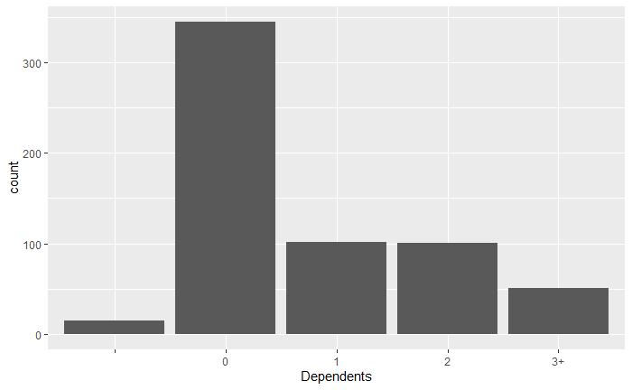

```r
ggplot(home.exp, aes(Dependents)) + geom_histogram(stat="count")
```

```
Ignoring unknown parameters: binwidth, bins, pad
```

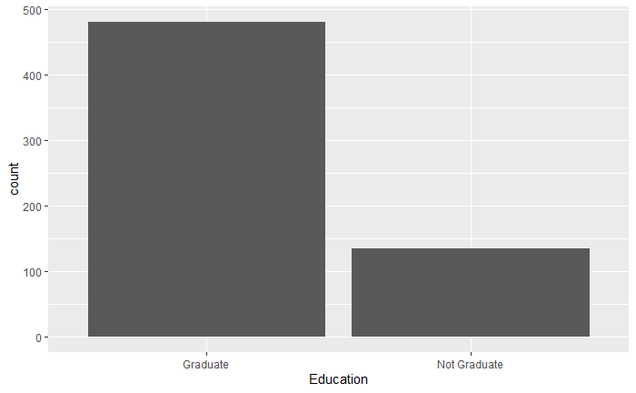

```r
ggplot(home.exp, aes(Education)) + geom_histogram(stat="count")
```

```
Ignoring unknown parameters: binwidth, bins, pad
```

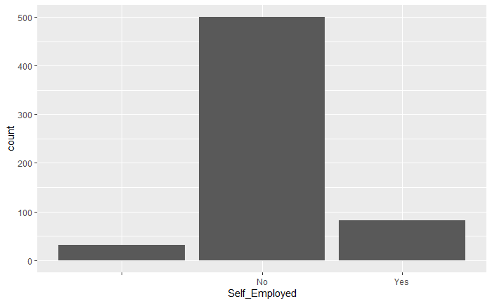

```r
ggplot(home.exp, aes(Self_Employed)) + geom_histogram(stat="count")
```

```
Ignoring unknown parameters: binwidth, bins, pad
```

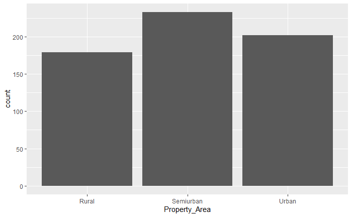

```r
ggplot(home.exp, aes(Property_Area)) + geom_histogram(stat="count")
```

```
Ignoring unknown parameters: binwidth, bins, pad
```

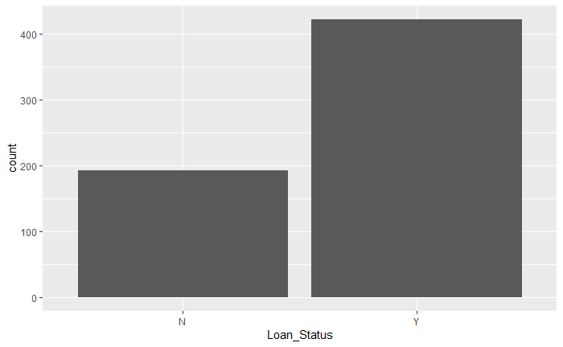

```r
ggplot(home.exp, aes(Loan_Status)) + geom_histogram(stat="count")
```

```
Ignoring unknown parameters: binwidth, bins, pad
```

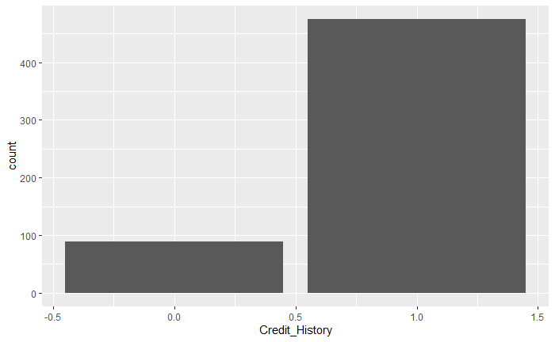

```r
ggplot(home.exp, aes(Credit_History)) + geom_histogram(stat="count")
```

Non-continuous variables missing counts

```r
home.exp[Gender == "", .N]
```

```
[1] 13
```

```r
home.exp[Married == "", .N]
```

```
[1] 3
```

```r
home.exp[Dependents == "", .N]
```

```
[1] 15
```

```r
home.exp[Self_Employed == "", .N]
```

```
[1] 32
```

```r
home.exp[is.na(Credit_History), .N]
```

```
[1] 50
```

Continuous variables missing counts

```r
home.exp[is.na(ApplicantIncome), .N]
```

```
[1] 0
```

```r
home.exp[is.na(CoapplicantIncome), .N]
```

```
[1] 0
```

```r
home.exp[is.na(LoanAmount), .N]
```

```
[1] 22
```

```r
home.exp[is.na(Loan_Amount_Term), .N]
```

```
[1] 14
```

# Filling missing categorical data

```r
# get mode function definition
getmode <- function(v) {
   uniqv <- unique(v)
   uniqv[which.max(tabulate(match(v, uniqv)))]
}
```

Create duplicate

```r
home <- copy(home.exp)
```

Impute with mode for Gender and Dependents column

```r
#get modes
gender.mode <- getmode(home.exp$Gender)
dependents.mode <- getmode(home.exp$Dependents)
self_employed.mode <- getmode(home.exp$Self_Employed)

#impute with modes
home[Gender=="", Gender:=gender.mode]
home[Dependents=="", Dependents:=dependents.mode]
home[Self_Employed=="", Self_Employed:=self_employed.mode]
home[is.na(Credit_History), Credit_History:=0] #reasonable to assume missing is none

#verify
levels(factor(home$Gender))
```

```
[1] "Female" "Male"
```

```r
levels(factor(home$Dependents))
```

```
[1] "0"  "1"  "2"  "3+"
```

```r
levels(factor(home$Self_Employed))
```

```
[1] "No"  "Yes"
```

```r
levels(factor(home$Credit_History))
```

```
[1] "0" "1"
```

Perform some profiling on the 3 missing married patterns Use Dependents and CoapplicantIncome

```r
# view the 3 with married missing
home[Married==""]
```

| Loan_ID | Gender | Married | Dependents | Education | Self_Employed | ApplicantIncome | CoapplicantIncome | LoanAmount | Loan_Amount_Term | Credit_History | Property_Area | Loan_Status |
| --- | --- | --- | --- | --- | --- | --- | --- | --- | --- | --- | --- | --- |
| LP001357 | Male |  | 0 | Graduate | No | 3816 | 754 | 160 | 360 | 1 | Urban | Y |
| LP001760 | Male |  | 0 | Graduate | No | 4758 | 0 | 158 | 480 | 1 | Semiurban | Y |
| LP002393 | Female |  | 0 | Graduate | No | 10047 | 0 | NA | 240 | 1 | Semiurban | Y |

```r
# get modes
LP001357.married.mode = getmode(home[Dependents == 0 & CoapplicantIncome > 0]$Married)
LP001760.LP002393.married.mode = getmode(home[Dependents == 0 & CoapplicantIncome == 0]$Married)

# impute with modes
home[Loan_ID=="LP001357", Married:=LP001357.married.mode]
home[Loan_ID=="LP001760" | Loan_ID=="LP002393", Married:=LP001760.LP002393.married.mode]

# verify
home[Loan_ID=="LP001357" | Loan_ID=="LP001760" | Loan_ID=="LP002393"]
```

| Loan_ID | Gender | Married | Dependents | Education | Self_Employed | ApplicantIncome | CoapplicantIncome | LoanAmount | Loan_Amount_Term | Credit_History | Property_Area | Loan_Status |
| --- | --- | --- | --- | --- | --- | --- | --- | --- | --- | --- | --- | --- |
| LP001357 | Male | Yes | 0 | Graduate | No | 3816 | 754 | 160 | 360 | 1 | Urban | Y |
| LP001760 | Male | No | 0 | Graduate | No | 4758 | 0 | 158 | 480 | 1 | Semiurban | Y |
| LP002393 | Female | No | 0 | Graduate | No | 10047 | 0 | NA | 240 | 1 | Semiurban | Y |

```r
summary(home) #verify
```

```
   Loan_ID             Gender            Married           Dependents         Education         Self_Employed      ApplicantIncome CoapplicantIncome
 Length:614         Length:614         Length:614         Length:614         Length:614         Length:614         Min.   :  150   Min.   :    0
 Class :character   Class :character   Class :character   Class :character   Class :character   Class :character   1st Qu.: 2878   1st Qu.:    0
 Mode  :character   Mode  :character   Mode  :character   Mode  :character   Mode  :character   Mode  :character   Median : 3812   Median : 1188
                                                                                                                   Mean   : 5403   Mean   : 1621
                                                                                                                   3rd Qu.: 5795   3rd Qu.: 2297
                                                                                                                   Max.   :81000   Max.   :41667

   LoanAmount    Loan_Amount_Term Credit_History   Property_Area      Loan_Status
 Min.   :  9.0   Min.   : 12      Min.   :0.0000   Length:614         Length:614
 1st Qu.:100.0   1st Qu.:360      1st Qu.:1.0000   Class :character   Class :character
 Median :128.0   Median :360      Median :1.0000   Mode  :character   Mode  :character
 Mean   :146.4   Mean   :342      Mean   :0.7736
 3rd Qu.:168.0   3rd Qu.:360      3rd Qu.:1.0000
 Max.   :700.0   Max.   :480      Max.   :1.0000
 NA's   :22      NA's   :14
```

# View distributions on filled data

It can be seen that the continuous variables have a small interquartile range in comparison to outliers - hard to see any distribution

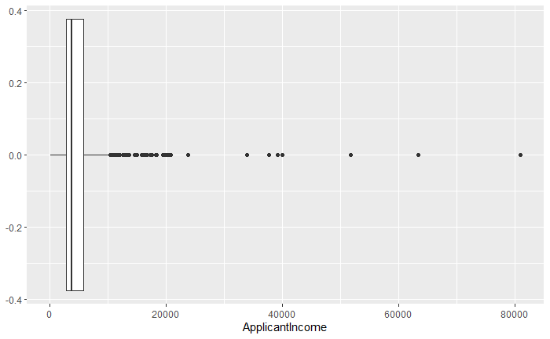

```r
ggplot(home, aes(ApplicantIncome)) + geom_boxplot()
```

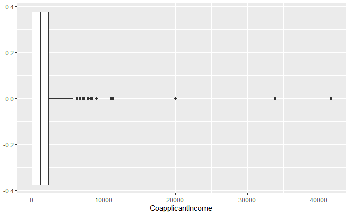

```r
ggplot(home, aes(CoapplicantIncome)) + geom_boxplot()
```

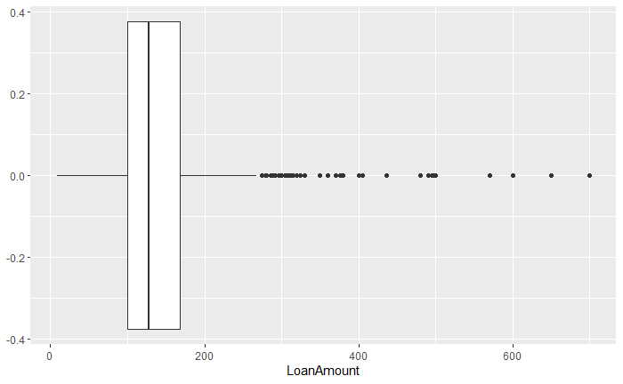

```r
ggplot(home[!is.na(LoanAmount)], aes(LoanAmount)) + geom_boxplot()
```

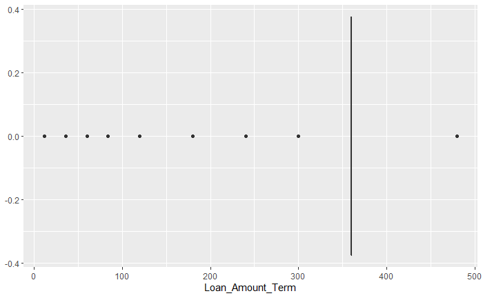

```r
ggplot(home[!is.na(Loan_Amount_Term)], aes(Loan_Amount_Term)) + geom_boxplot()
```

View distributions in their raw state - Notice that Loan_Amount_Term is overwhelmingly 360 days (1 year)

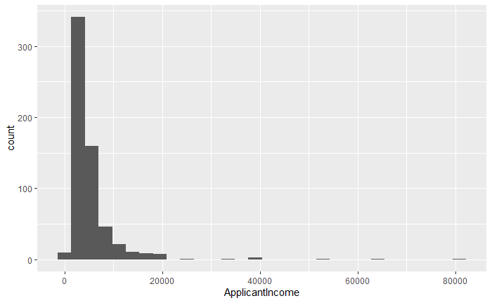

```r
ggplot(home, aes(ApplicantIncome)) + geom_histogram()
```

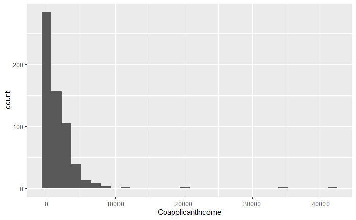

```r
ggplot(home, aes(CoapplicantIncome)) + geom_histogram()
```

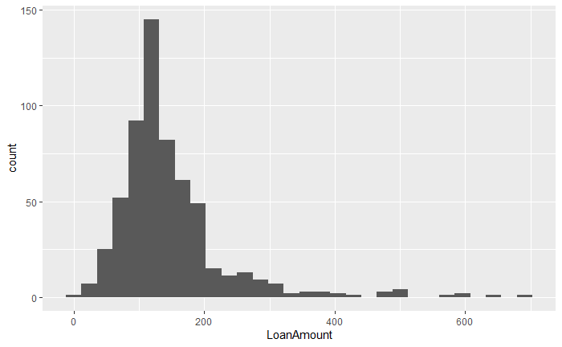

```r
ggplot(home[!is.na(LoanAmount)], aes(LoanAmount)) + geom_histogram()
```

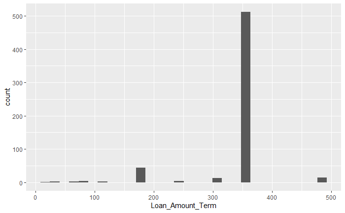

```r
ggplot(home[!is.na(Loan_Amount_Term)], aes(Loan_Amount_Term)) + geom_histogram()
```

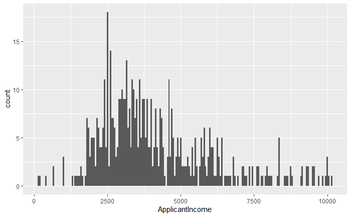

```r
# grab range for non-outliers
ai.q <- quantile(home$ApplicantIncome, probs = c(.25, .75), na.rm = FALSE)
ai.iqr <- IQR(home$ApplicantIncome)
cai.q <- quantile(home$CoapplicantIncome, probs = c(.25, .75), na.rm = FALSE)
cai.iqr <- IQR(home$CoapplicantIncome)
la.q <- quantile(home[!is.na(LoanAmount)]$LoanAmount, probs = c(.25, .75), na.rm = FALSE)
la.iqr <- IQR(home[!is.na(LoanAmount)]$LoanAmount)

# plot
ggplot(home[ApplicantIncome > ai.q[1]-1.5*ai.iqr & ApplicantIncome < ai.q[2]+1.5*ai.iqr], aes(ApplicantIncome)) + geom_histogram(binwidth = 50)
```

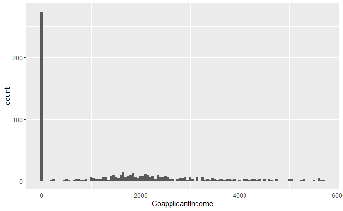

```r
ggplot(home[CoapplicantIncome > cai.q[1]-1.5*cai.iqr & CoapplicantIncome <= cai.q[2]+1.5*cai.iqr], aes(CoapplicantIncome)) + geom_histogram(binwidth = 50)
```

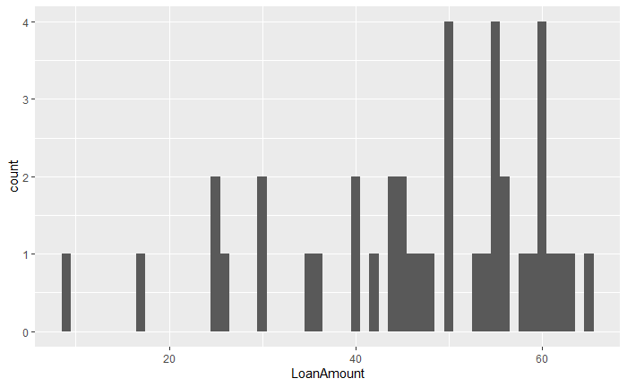

```r
ggplot(home[!is.na(LoanAmount) & LoanAmount > la.q[1]-1.5*la.iqr & LoanAmount < la.q[2]-1.5*la.iqr], aes(LoanAmount)) + geom_histogram(binwidth = 1)
```

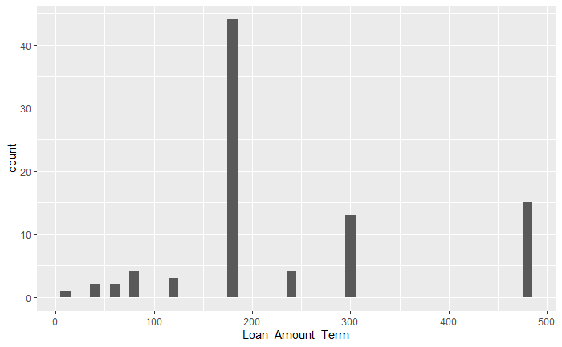

```r
ggplot(home[!is.na(Loan_Amount_Term) & Loan_Amount_Term != 360], aes(Loan_Amount_Term)) + geom_histogram(binwidth = 10)
```

Since there is large amount of people with 0 Coapplicant, see distribution of non-zero, barring outliers

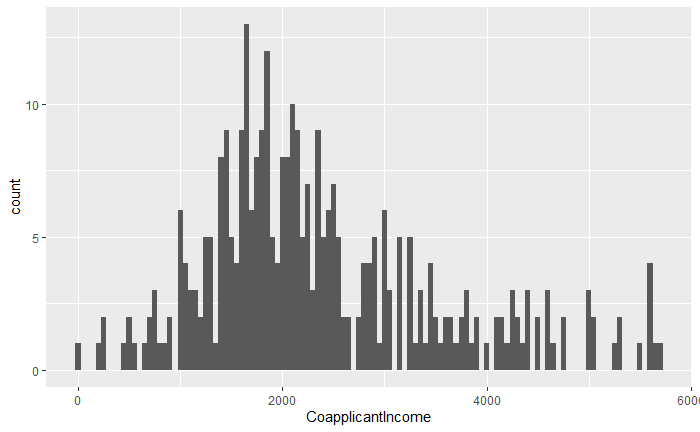

```r
ggplot(home[CoapplicantIncome > cai.q[1]-1.5*cai.iqr & CoapplicantIncome <= cai.q[2]+1.5*cai.iqr & CoapplicantIncome != 0], aes(CoapplicantIncome)) + geom_histogram(binwidth = 50)
```

# Data cleaning for Loan Amount to give

Find correlations for approved loans - LoanAmount and ApplicantIncome seem to have a somewhat positive correlation

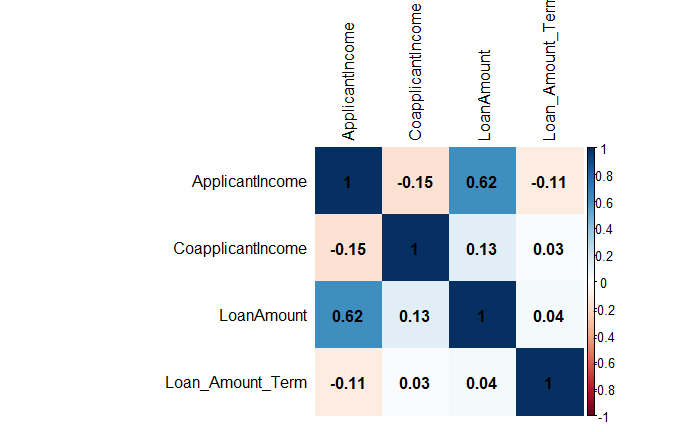

```r
corr.matrix <- cor(home[Loan_Status=="Y",c('ApplicantIncome','CoapplicantIncome','LoanAmount','Loan_Amount_Term')], use='complete.obs')
corrplot(corr.matrix, method="color",addCoef.col = "black",tl.col = "black")
```

Try looking at scatter plot - it appears that the correlation may only be present because of outliers

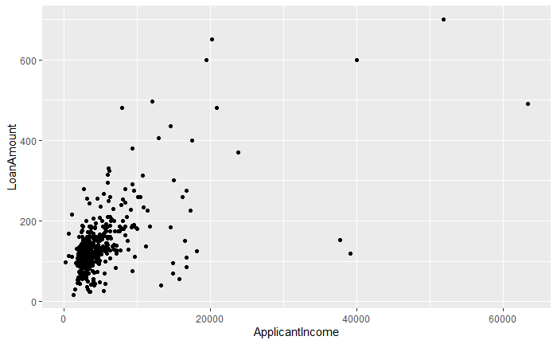

```r
ggplot(home[Loan_Status=="Y"], aes(x=ApplicantIncome, y=LoanAmount)) + geom_point()
```

Try scatterplot and correlation without outliers - correlation becomes less strong but still visible

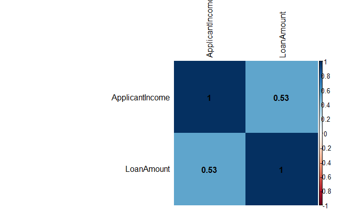

```r
corr.matrix <- cor(home[Loan_Status=="Y" & ApplicantIncome < 20000,c('ApplicantIncome', 'LoanAmount')], use='complete.obs')
corrplot(corr.matrix, method="color",addCoef.col = "black",tl.col = "black")
```

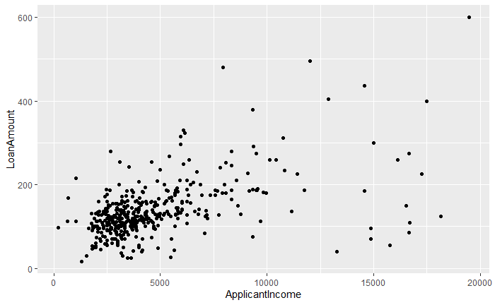

```r
ggplot(home[Loan_Status=="Y" & ApplicantIncome < 20000], aes(x=ApplicantIncome, y=LoanAmount)) + geom_point()
```

## Feature Engineering

Maybe create new features? - impute missing values - combined income - LoanAmount / LoanAmountTerm * 30 to compare with income

```r
# copy
home.loan <- copy(home[Loan_Status=="Y"])

# impute rows with missing loan information using mean
loanamount.mean <- as.integer(mean(home.loan$LoanAmount, na.rm = TRUE))
loanamountterm.mean <- as.integer(mean(home.loan$Loan_Amount_Term, na.rm=TRUE))
home.loan[is.na(LoanAmount), LoanAmount:=loanamount.mean]
home.loan[is.na(Loan_Amount_Term), Loan_Amount_Term:=loanamountterm.mean]

# verify imputation
sum(is.na(home.loan$LoanAmount))
```

```
[1] 0
```

```r
sum(is.na(home.loan$Loan_Amount_Term))
```

```
[1] 0
```

```r
# combine income
home.loan[,Income:=as.integer(ApplicantIncome+CoapplicantIncome)]
# create new loan amount
home.loan[,LoanMonthly:=LoanAmount/Loan_Amount_Term*30]

# verify
head(home.loan)
```

| Loan_ID | Gender | Married | Dependents | Education | Self_Employed | ApplicantIncome | CoapplicantIncome | LoanAmount | Loan_Amount_Term | Credit_History | Property_Area | Loan_Status | Income | LoanMonthly |
| --- | --- | --- | --- | --- | --- | --- | --- | --- | --- | --- | --- | --- | --- | --- |
| LP001002 | Male | No | 0 | Graduate | No | 5849 | 0 | 144 | 360 | 1 | Urban | Y | 5849 | 12.000000 |
| LP001005 | Male | Yes | 0 | Graduate | Yes | 3000 | 0 | 66 | 360 | 1 | Urban | Y | 3000 | 5.500000 |
| LP001006 | Male | Yes | 0 | Not Graduate | No | 2583 | 2358 | 120 | 360 | 1 | Urban | Y | 4941 | 10.000000 |
| LP001008 | Male | No | 0 | Graduate | No | 6000 | 0 | 141 | 360 | 1 | Urban | Y | 6000 | 11.750000 |
| LP001011 | Male | Yes | 2 | Graduate | Yes | 5417 | 4196 | 267 | 360 | 1 | Urban | Y | 9613 | 22.250000 |
| LP001013 | Male | Yes | 0 | Not Graduate | No | 2333 | 1516 | 95 | 360 | 1 | Urban | Y | 3849 | 7.916667 |

Check new correlations - random outlier (Loanmonthly > 250) is skewing correlations (should remove in cleaning)

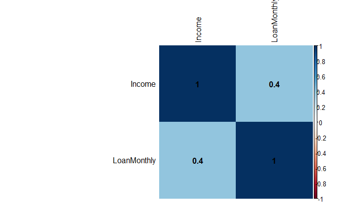

```r
corr.matrix <- cor(home.loan[,c('Income', 'LoanMonthly')], use='complete.obs')
corrplot(corr.matrix, method="color",addCoef.col = "black",tl.col = "black")
```

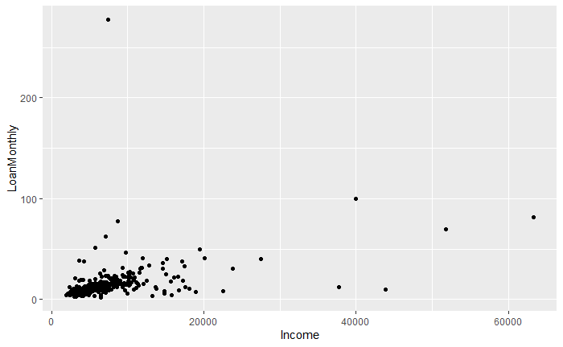

```r
ggplot(home.loan, aes(x=Income, y=LoanMonthly)) + geom_point()
```

Find correlations without outlier - much stronger and better

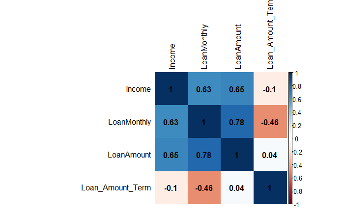

```r
corr.matrix <- cor(home.loan[LoanMonthly<250,c('Income', 'LoanMonthly', 'LoanAmount', 'Loan_Amount_Term')], use='complete.obs')
corrplot(corr.matrix, method="color",addCoef.col = "black",tl.col = "black")
```

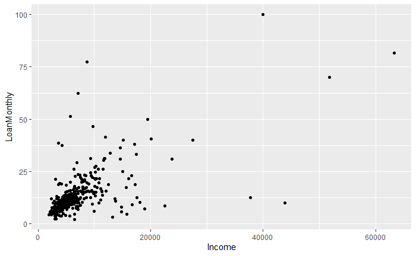

```r
ggplot(home.loan[LoanMonthly<250], aes(x=Income, y=LoanMonthly)) + geom_point()
```

See distribution wihtout outlier

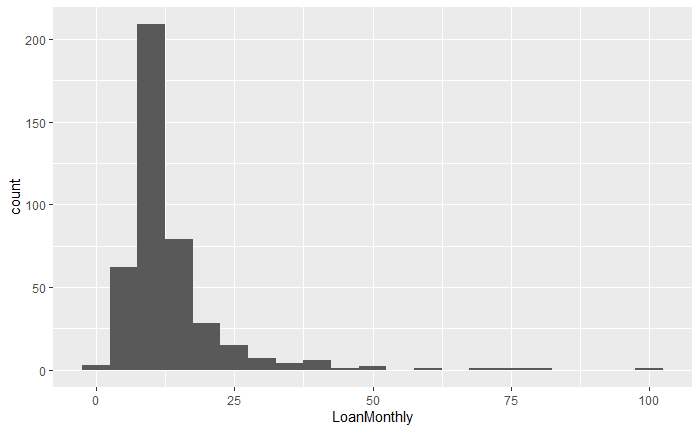

```r
ggplot(home.loan[LoanMonthly<250], aes(LoanMonthly)) + geom_histogram(binwidth = 5)
```

```r
mean(home.loan$LoanMonthly)
```

```
[1] 14.13607
```

Remove outlier

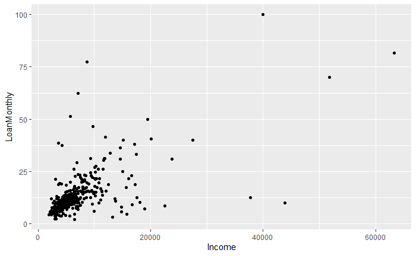

```r
home.loan.no.outlier <- home.loan[LoanMonthly < 250]
ggplot(home.loan.no.outlier, aes(x=Income, y=LoanMonthly)) + geom_point()
```

Factor the categorical columns

```r
cols <- c("Gender", "Married", "Dependents", "Education", "Self_Employed", "Property_Area", "Loan_Status")
home.loan.no.outlier[,cols] <- lapply(home.loan.no.outlier[,cols, with=FALSE], factor)
```

```r
summary(home.loan.no.outlier)
```

```
   Loan_ID             Gender    Married   Dependents        Education   Self_Employed ApplicantIncome CoapplicantIncome   LoanAmount
 Length:421         Female: 75   No :136   0 :246     Graduate    :339   No :365       Min.   :  210   Min.   :    0     Min.   : 17.0
 Class :character   Male  :346   Yes:285   1 : 66     Not Graduate: 82   Yes: 56       1st Qu.: 2876   1st Qu.:    0     1st Qu.:100.0
 Mode  :character                          2 : 76                                      Median : 3812   Median : 1229     Median :128.0
                                           3+: 33                                      Mean   : 5386   Mean   : 1501     Mean   :144.4
                                                                                       3rd Qu.: 5780   3rd Qu.: 2283     3rd Qu.:160.0
                                                                                       Max.   :63337   Max.   :20000     Max.   :700.0
 Loan_Amount_Term Credit_History     Property_Area Loan_Status     Income       LoanMonthly
 Min.   : 60.0    Min.   :0.0000   Rural    :110   Y:421       Min.   : 1963   Min.   :  2.167
 1st Qu.:360.0    1st Qu.:1.0000   Semiurban:179               1st Qu.: 4188   1st Qu.:  8.583
 Median :360.0    Median :1.0000   Urban    :132               Median : 5428   Median : 10.833
 Mean   :341.9    Mean   :0.8979                               Mean   : 6887   Mean   : 13.511
 3rd Qu.:360.0    3rd Qu.:1.0000                               3rd Qu.: 7451   3rd Qu.: 14.667
 Max.   :480.0    Max.   :1.0000                               Max.   :63337   Max.   :100.000
```

Save file

```r
fwrite(home.loan.no.outlier, file="home_loan_structure_prediction.csv")
```

# Data cleaning for Loan Eligibility

Perform imputation + feature engineering

```r
# copy
home.eligibility <- copy(home)

# impute rows with missing loan information using mean
loanamount.mean <- as.integer(mean(home.eligibility$LoanAmount, na.rm = TRUE))
loanamountterm.mean <- as.integer(mean(home.eligibility$Loan_Amount_Term, na.rm=TRUE))
home.eligibility[is.na(LoanAmount), LoanAmount:=loanamount.mean]
home.eligibility[is.na(Loan_Amount_Term), Loan_Amount_Term:=loanamountterm.mean]

# feature engineering (create LoanMonthly and Income columns)
loanamount.mean <- as.integer(mean(home.eligibility$LoanAmount, na.rm = TRUE))
loanamountterm.mean <- as.integer(mean(home.eligibility$Loan_Amount_Term, na.rm=TRUE))
home.eligibility[is.na(LoanAmount), LoanAmount:=loanamount.mean]
home.eligibility[is.na(Loan_Amount_Term), Loan_Amount_Term:=loanamountterm.mean]

# combine income
home.eligibility[,Income:=as.integer(ApplicantIncome+CoapplicantIncome)]
# create new loan amount
home.eligibility[,LoanMonthly:=LoanAmount/Loan_Amount_Term*30]
```

Factor Categorical columns

```r
cols <- c("Gender", "Married", "Dependents", "Education", "Self_Employed", "Property_Area", "Loan_Status")
home.eligibility[,cols] <- lapply(home.eligibility[,cols, with=FALSE], factor)
```

Data exploration revealed nearly 2:1 Y vs N, need to balance dataset

```r
# undersampling to balance the Y and N
home.eligibility[Loan_Status=="N",.N]
```

```
[1] 192
```

```r
yes.id <- sample(home.eligibility[Loan_Status=="Y"]$Loan_ID, size=192)
home.eligibility.balanced <- home.eligibility[Loan_ID %in% yes.id | Loan_Status=="N"]

#verify
summary(home.eligibility.balanced)
```

```
   Loan_ID             Gender    Married   Dependents        Education   Self_Employed ApplicantIncome CoapplicantIncome   LoanAmount
 Length:384         Female: 69   No :137   0 :239     Graduate    :299   No :329       Min.   :  150   Min.   :    0     Min.   :  9.0
 Class :character   Male  :315   Yes:247   1 : 59     Not Graduate: 85   Yes: 55       1st Qu.: 2748   1st Qu.:    0     1st Qu.:102.0
 Mode  :character                          2 : 57                                      Median : 3717   Median : 1168     Median :132.0
                                           3+: 29                                      Mean   : 5502   Mean   : 1684     Mean   :149.4
                                                                                       3rd Qu.: 5754   3rd Qu.: 2344     3rd Qu.:165.0
                                                                                       Max.   :81000   Max.   :41667     Max.   :700.0
 Loan_Amount_Term Credit_History     Property_Area Loan_Status     Income       LoanMonthly
 Min.   : 36.0    Min.   :0.0000   Rural    :120   N:192       Min.   : 1442   Min.   :  0.750
 1st Qu.:360.0    1st Qu.:0.0000   Semiurban:134   Y:192       1st Qu.: 4080   1st Qu.:  8.667
 Median :360.0    Median :1.0000   Urban    :130               Median : 5240   Median : 11.250
 Mean   :342.1    Mean   :0.7005                               Mean   : 7187   Mean   : 14.389
 3rd Qu.:360.0    3rd Qu.:1.0000                               3rd Qu.: 7346   3rd Qu.: 15.233
 Max.   :480.0    Max.   :1.0000                               Max.   :81000   Max.   :129.167
```

Save file

```r
fwrite(home.eligibility.balanced, file="home_eligibility_prediction.csv")
```